# Practical Machine Learning Course Project

Tom de Witt

Sunday, June 21, 2015

# Practical Machine Learning Course Project - Weight lifting

## Executive Summary

Six young health participants were asked to perform one set of 10 repetitions of the Unilateral Dumbbell Biceps Curl in five different fashions: exactly according to the specification (Class A), throwing the elbows to the front (Class B), lifting the dumbbell only halfway (Class C), lowering the dumbbell only halfway (Class D) and throwing the hips to the front (Class E). Class A corresponds to the specified execution of the exercise, while the other 4 classes correspond to common mistakes. Participants were supervised by an experienced weight lifter to make sure the execution complied to the manner they were supposed to simulate. The exercises were performed by six male participants aged between 20-28 years, with little weight lifting experience. We made sure that all participants could easily simulate the mistakes in a safe and controlled manner by using a relatively light dumbbell (1.25kg).

The `Random Forest` model appear to be an excellent model for prediction in this study.

Read more: http://groupware.les.inf.puc-rio.br/har#weight_lifting_exercises

The main objectives of this project are as follows:

- Predict the manner in which they did the exercise depicted by the `classe` variable.
- Build a prediction model.
- Calculate the out of sample error.
- Use the prediction model to predict `20` different test cases provided.

### Load libraries

Load the required libraries.

```
##        knitr        caret          gbm         plyr randomForest
##         TRUE         TRUE         TRUE         TRUE         TRUE
```

### Getting the data

Load the training and test data sets.

```r
# read training and testing data for coursera course.
trainUrl <- "http://d396qusza40orc.cloudfront.net/predmachlearn/pml-training.csv"
testUrl <- "http://d396qusza40orc.cloudfront.net/predmachlearn/pml-testing.csv"
training <- read.csv(url(trainUrl), header = TRUE, sep = ",", na.strings = c("NA", "#DIV/0!", ""))
testing <- read.csv(url(testUrl), header = TRUE, sep = ",", na.strings = c("NA", "#DIV/0!", ""))
```

### Cleaning and preparing the data

Notice that the last column of the test set is different (problem_id) from the last column of the training set (classe). Apply the same transformations on both your training and testing set.

```r
# Remove unnecessary columns

# first 7 columns don't contain useful info
training <- training[, -seq(1:7)]
testing <- testing[, -seq(1:7)]

# remove columns that have more than 20% NA's

naColumns <- colSums(is.na(training)) > nrow(training) * 0.2
training <- training[, !naColumns]
testing <- testing[, !naColumns]

# remove columns with near zero variance
nearZeroVarColumns <- nearZeroVar(training, saveMetrics = TRUE)
training <- training[, !nearZeroVarColumns$nzv]
testing <- testing[, !nearZeroVarColumns$nzv]

dim(training)
```

```
## [1] 19622    53
```

```r
dim(testing)
```

```
## [1] 20 53
```

```r
# check for NAs in cleaned set.
sum(complete.cases(training)) == nrow(training)
```

```
## [1] TRUE
```

```r
sum(complete.cases(testing)) == nrow(testing)
```

```
## [1] TRUE
```

### Train Models

Build a machine learning model for predicting the `classe` value based on the other features of the dataset.

#### Data partitioning

Partition the `training` dataset into training and testing data sets for building our model.

```r
partition <- createDataPartition(y = training$classe, p = 0.6, list = FALSE)
trainingdata <- training[partition, ]
testdata <- training[-partition, ]
```

#### Cross validation Use Cross validation to determine how well the model will generalize.

```r
fitControl <- trainControl(method = "cv", number = 2, , allowParallel = TRUE)
```

Using `2-fold` cross validation.

#### Model building: Boosting with trees

```r
gbmFit <- train(classe ~ ., data = trainingdata, method = "gbm", trControl = fitControl, verbose = FALSE)
gbmFit
```

```
## Stochastic Gradient Boosting
##
## 11776 samples
##    52 predictor
##     5 classes: 'A', 'B', 'C', 'D', 'E'
##
## No pre-processing
## Resampling: Cross-Validated (2 fold)
##
## Summary of sample sizes: 5888, 5888
##
## Resampling results across tuning parameters:
##
##   interaction.depth  n.trees  Accuracy   Kappa      Accuracy SD  Kappa SD
##   1                   50      0.7504246  0.6836726  0.003482693  0.003861824
##   1                  100      0.8196332  0.7717441  0.001681300  0.002256067
##   1                  150      0.8523268  0.8130883  0.002521950  0.003064112
##   2                   50      0.8504586  0.8105091  0.006124736  0.008045585
##   2                  100      0.8995414  0.8728545  0.002521950  0.003148618
##   2                  150      0.9253567  0.9055438  0.002521950  0.003174665
##   3                   50      0.8939368  0.8656961  0.001321022  0.001577563
##   3                  100      0.9335938  0.9159737  0.007445758  0.009403556
##   3                  150      0.9519361  0.9391911  0.001921486  0.002429875
##
## Tuning parameter 'shrinkage' was held constant at a value of 0.1
## Tuning parameter 'n.minobsinnode' was held constant
##  at a value of 10
## Accuracy was used to select the optimal model using  the largest value.
## The final values used for the model were n.trees = 150, interaction.depth = 3, shrinkage = 0.1 and n.minobsinnode = 10.
```

```r
# Validate: Boosting with trees</u>

gbm_pred <- predict(gbmFit, testdata)
gbmConfusionMatrix <- confusionMatrix(gbm_pred, testdata$classe)
gbmConfusionMatrix
```

```
## Confusion Matrix and Statistics
##
##           Reference
## Prediction    A    B    C    D    E
##          A 2191   58    0    2    4
##          B   26 1421   45   10   20
##          C    6   37 1307   39   13
##          D    5    0   12 1226   19
##          E    4    2    4    9 1386
##
## Overall Statistics
##
##                Accuracy : 0.9599
##                  95% CI : (0.9553, 0.9641)
##     No Information Rate : 0.2845
##     P-Value [Acc > NIR] : < 2.2e-16
##
##                   Kappa : 0.9492
##  Mcnemar's Test P-Value : 1.278e-10
##
## Statistics by Class:
##
##                      Class: A Class: B Class: C Class: D Class: E
## Sensitivity            0.9816   0.9361   0.9554   0.9533   0.9612
## Specificity            0.9886   0.9840   0.9853   0.9945   0.9970
## Pos Pred Value         0.9716   0.9336   0.9322   0.9715   0.9865
## Neg Pred Value         0.9927   0.9847   0.9905   0.9909   0.9913
## Prevalence             0.2845   0.1935   0.1744   0.1639   0.1838
## Detection Rate         0.2793   0.1811   0.1666   0.1563   0.1767
## Detection Prevalence   0.2874   0.1940   0.1787   0.1608   0.1791
## Balanced Accuracy      0.9851   0.9601   0.9704   0.9739   0.9791
```

```r
# Accuracy
gbmAccuracy <- round(gbmConfusionMatrix$overall["Accuracy"] * 100, 2)
```

The `out of sample` accuracy value for Boosting with trees is 95.99%.

#### Model building: Random Forest

Build our model using the `Random Forest` machine learning technique.

```r
rfFit <- train(classe ~ ., data = trainingdata, method = "rf", prox = TRUE, trControl = trainControl(method = "cv", number = 2,
    allowParallel = TRUE))
rfFit
```

```
## Random Forest
##
## 11776 samples
##    52 predictor
##     5 classes: 'A', 'B', 'C', 'D', 'E'
##
## No pre-processing
## Resampling: Cross-Validated (2 fold)
##
## Summary of sample sizes: 5887, 5889
##
## Resampling results across tuning parameters:
##
##   mtry  Accuracy   Kappa      Accuracy SD  Kappa SD
##    2    0.9802987  0.9750699  0.001926218  0.002442752
##   27    0.9819118  0.9771145  0.004687966  0.005933432
##   52    0.9755433  0.9690572  0.001206803  0.001529414
##
## Accuracy was used to select the optimal model using  the largest value.
## The final value used for the model was mtry = 27.
```

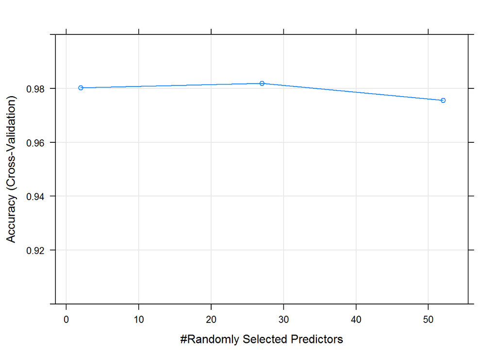

```r
plot(rfFit, ylim = c(0.9, 1))
```

#### Variable Importance

```r
imp <- varImp(rfFit, scale = FALSE)
imp
```

```
## rf variable importance
##
##   only 20 most important variables shown (out of 52)
##
##                      Overall
## roll_belt             1190.7
## pitch_forearm          704.9
## yaw_belt               674.3
## magnet_dumbbell_z      583.0
## pitch_belt             530.9
## magnet_dumbbell_y      526.8
## roll_forearm           467.7
## accel_dumbbell_y       272.7
## magnet_dumbbell_x      240.2
## roll_dumbbell          227.7
## accel_forearm_x        225.1
## magnet_belt_z          204.4
## accel_belt_z           191.6
## accel_dumbbell_z       191.1
## magnet_forearm_z       176.7
## total_accel_dumbbell   173.6
## yaw_arm                162.7
## gyros_belt_z           160.5
## magnet_belt_y          155.3
## magnet_belt_x          133.3
```

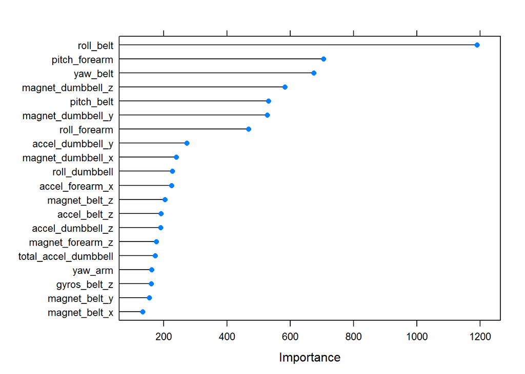

```r
plot(imp, top = 20)
```

#### In sample accuracy

Calculate the prediction accuracy of the model on the training data set.

```r
training_pred <- predict(rfFit, trainingdata)
rfConfusionMatrix <- confusionMatrix(training_pred, trainingdata$classe)
rfConfusionMatrix
```

```
## Confusion Matrix and Statistics
##
##           Reference
## Prediction    A    B    C    D    E
##          A 3348    0    0    0    0
##          B    0 2279    0    0    0
##          C    0    0 2054    0    0
##          D    0    0    0 1930    0
##          E    0    0    0    0 2165
##
## Overall Statistics
##
##                Accuracy : 1
##                  95% CI : (0.9997, 1)
##     No Information Rate : 0.2843
##     P-Value [Acc > NIR] : < 2.2e-16
##
##                   Kappa : 1
##  Mcnemar's Test P-Value : NA
##
## Statistics by Class:
##
##                      Class: A Class: B Class: C Class: D Class: E
## Sensitivity            1.0000   1.0000   1.0000   1.0000   1.0000
## Specificity            1.0000   1.0000   1.0000   1.0000   1.0000
## Pos Pred Value         1.0000   1.0000   1.0000   1.0000   1.0000
## Neg Pred Value         1.0000   1.0000   1.0000   1.0000   1.0000
## Prevalence             0.2843   0.1935   0.1744   0.1639   0.1838
## Detection Rate         0.2843   0.1935   0.1744   0.1639   0.1838
## Detection Prevalence   0.2843   0.1935   0.1744   0.1639   0.1838
## Balanced Accuracy      1.0000   1.0000   1.0000   1.0000   1.0000
```

```r
# Accuracy
rfAccuracy1 <- round(rfConfusionMatrix$overall["Accuracy"] * 100, 2)
```

The `in sample` accuracy value is Rand Forest is 100%.

#### Out of sample accuracy

Calculate the prediction accuracy of our model on the testing data set.

```r
testing_pred <- predict(rfFit, testdata)
rfConfusionMatrix2 <- confusionMatrix(testing_pred, testdata$classe)

# Accuracy
rfAccuracy2 <- round(rfConfusionMatrix2$overall["Accuracy"] * 100, 2)
```

The `out of sample` accuracy value is 99.25%.

## Prediction

Apply the model to each of the 20 test cases in the testing data set.

```r
answers <- predict(rfFit, testing)
answers <- as.character(answers)
answers
```

```
##  [1] "B" "A" "B" "A" "A" "E" "D" "B" "A" "A" "B" "C" "B" "A" "E" "E" "A" "B" "B" "B"
```

Write the answers to files.

```r
pml_write_files = function(x) {
    n = length(x)
    for (i in 1:n) {
        filename = paste0("problem_id_", i, ".txt")
        write.table(x[i], file = filename, quote = FALSE, row.names = FALSE, col.names = FALSE)
    }
}

pml_write_files(answers)
```

## Conclusion

`Random Forest` is chosen as machine learning algorithm for building our model because,

- Builds a highly accurate classifier.
- Can handle thousands of variables.
- Balances bias and variance trade-offs by settling for a balanced model.
- Using `k-fold` cross validation builds a robust model.

The `Random Forest` model appear to be an excellent model for prediction in this study.